# Project name : “Final Project”

# Code author name : Huda Fatima, Mohd Adnaan Khan, Amina Khatun

# Course: HDS 5310

# Project Purpose: The purpose of this project is to examine how environmental and social determinants—including air pollution (e.g., PM2.5), land development, and socioeconomic conditions—are associated with lung cancer incidence across U.S. counties.

# Date last edited : 04-29-2025

```r
#load the neccesary libraries
library(tidyverse)
library(car)
library(lmtest)
```

```r
library(readxl)
library(dplyr)
library(ggplot2)
```

```r
#load the dataset
lung.cancer.incidence <- read_excel("C:/Users/drhud/Downloads/Data_Set_Final_LTD_Slope_Intercept (1).xlsx")
```

```r
#View the first few rows of the dataset to get an overview of the structure and values
head(lung.cancer.incidence)
```

```
## # A tibble: 6 × 34
##   FIPS_code County   State `Lung Cancer` PM2.5 `Status Variable` Land_EQI
##       <dbl> <chr>    <chr>         <dbl> <dbl>             <dbl>    <dbl>
## 1      1001 Autauga  AL             73.9  12.1                 1   -0.707
## 2      1003 Baldwin  AL             68.4  11.1                 1   -1.08
## 3      1005 Barbour  AL             76.1  12.4                 1   -1.28
## 4      1007 Bibb Cou AL             86.4  12.2                 1   -0.827
## 5      1009 Blount C AL             73.1  13.0                 1   -0.623
## 6      1011 Bullock  AL             72.4  12.2                 1   -1.26
## # ℹ 27 more variables: Sociod_EQI <dbl>, Built_EQI <dbl>, LTD <dbl>,
## #   Intercept <dbl>, Slope <dbl>, CLU50_1 <dbl>, PM10 <dbl>, SO2 <dbl>,
## #   NO2 <dbl>, O3 <dbl>, CO <dbl>, CN <dbl>, Disel <dbl>, CS2 <dbl>,
## #   Air_EQI <dbl>, Water_EQI <dbl>, EQI <dbl>, Status <dbl>, LCI <dbl>,
## #   UCI <dbl>, Inter <dbl>, Slp <dbl>, control <dbl>, treat <dbl>,
## #   Local_Treat <dbl>, AAC <dbl>, RT <chr>
```

```r
#View the last few rows of the dataset to check for any trailing NA values or inconsistencies
tail(lung.cancer.incidence)
```

```
## # A tibble: 6 × 34
##   FIPS_code County   State `Lung Cancer` PM2.5 `Status Variable` Land_EQI
##       <dbl> <chr>    <chr>         <dbl> <dbl>             <dbl>    <dbl>
## 1     56033 Sheridan WY             49.9  7.57                 0    0.283
## 2     56037 Sweetwat WY             45.3  6.4                  0    0.329
## 3     56039 Teton Co WY             22.6  6.67                 0    0.317
## 4     56041 Uinta Co WY             37.1  6.57                 0    0.253
## 5     56043 Washakie WY             51.1  6.33                 0    0.151
## 6     56045 Weston C WY             46.4  5.24                 0    0.298
## # ℹ 27 more variables: Sociod_EQI <dbl>, Built_EQI <dbl>, LTD <dbl>,
## #   Intercept <dbl>, Slope <dbl>, CLU50_1 <dbl>, PM10 <dbl>, SO2 <dbl>,
## #   NO2 <dbl>, O3 <dbl>, CO <dbl>, CN <dbl>, Disel <dbl>, CS2 <dbl>,
## #   Air_EQI <dbl>, Water_EQI <dbl>, EQI <dbl>, Status <dbl>, LCI <dbl>,
## #   UCI <dbl>, Inter <dbl>, Slp <dbl>, control <dbl>, treat <dbl>,
## #   Local_Treat <dbl>, AAC <dbl>, RT <chr>
```

```r
#Generate summary statistics for each variable
summary(lung.cancer.incidence)
```

```
##    FIPS_code        County             State            Lung Cancer
##  Min.   : 1001   Length:2602        Length:2602        Min.   : 12.90
##  1st Qu.:18028   Class :character   Class :character   1st Qu.: 58.00
##  Median :31002   Mode  :character   Mode  :character   Median : 68.60
##  Mean   :30741                                         Mean   : 69.17
##  3rd Qu.:46081                                         3rd Qu.: 79.40
##  Max.   :56045                                         Max.   :169.90
##
##      PM2.5        Status Variable     Land_EQI          Sociod_EQI
##  Min.   : 1.700   Min.   :0.0000   Min.   :-5.11581   Min.   :-4.809990
##  1st Qu.: 8.453   1st Qu.:0.0000   1st Qu.:-0.40068   1st Qu.:-0.649570
##  Median :10.650   Median :1.0000   Median : 0.17488   Median : 0.004630
##  Mean   :10.125   Mean   :0.5058   Mean   : 0.03327   Mean   : 0.009265
##  3rd Qu.:11.860   3rd Qu.:1.0000   3rd Qu.: 0.64774   3rd Qu.: 0.617387
##  Max.   :16.910   Max.   :1.0000   Max.   : 2.09453   Max.   : 3.979472
##
##    Built_EQI             LTD           Intercept          Slope
##  Min.   :-3.99272   Min.   :-22.44   Min.   :-32.97   Min.   :-1.150
##  1st Qu.:-0.43898   1st Qu.:  5.86   1st Qu.: 32.46   1st Qu.: 2.250
##  Median : 0.17925   Median : 10.52   Median : 35.42   Median : 3.150
##  Mean   : 0.07986   Mean   : 12.29   Mean   : 38.22   Mean   : 3.068
##  3rd Qu.: 0.68986   3rd Qu.: 15.26   3rd Qu.: 45.59   3rd Qu.: 3.440
##  Max.   : 3.88379   Max.   : 50.64   Max.   : 89.59   Max.   :10.540
##
##     CLU50_1           PM10             SO2                NO2
##  Min.   : 1.00   Min.   : 1.220   Min.   :    1.00   Min.   :   1.012
##  1st Qu.:13.00   1st Qu.: 8.155   1st Qu.:   44.65   1st Qu.: 234.953
##  Median :24.00   Median :11.530   Median :  143.10   Median : 457.056
##  Mean   :25.21   Mean   :11.905   Mean   :  233.54   Mean   : 592.969
##  3rd Qu.:40.00   3rd Qu.:14.770   3rd Qu.:  307.14   3rd Qu.: 779.318
##  Max.   :50.00   Max.   :39.550   Max.   :12180.53   Max.   :8661.627
##
##        O3                 CO                  CN                Disel
##  Min.   :    1.64   Min.   :    1.112   Min.   :0.0001281   Min.   :0.01688
##  1st Qu.: 2895.29   1st Qu.:  185.524   1st Qu.:0.0071636   1st Qu.:0.19244
##  Median : 4574.93   Median :  356.301   Median :0.0154060   Median :0.29696
##  Mean   : 5126.00   Mean   :  604.817   Mean   :0.0242717   Mean   :0.39313
##  3rd Qu.: 6594.43   3rd Qu.:  952.495   3rd Qu.:0.0304405   3rd Qu.:0.46681
##  Max.   :80276.76   Max.   :24815.739   Max.   :1.3493422   Max.   :8.81512
##
```

[output cut: 17 more lines]

```
##  Min.   :-70.630   Min.   :39.70   Min.   :40.84   Min.   :-22.440
##  1st Qu.:  1.695   1st Qu.:58.80   1st Qu.:70.62   1st Qu.:  4.284
##  Median :  2.905   Median :62.46   Median :76.39   Median :  8.531
##  Mean   :  1.543   Mean   :64.12   Mean   :74.50   Mean   : 10.849
##  3rd Qu.:  3.647   3rd Qu.:69.90   3rd Qu.:78.29   3rd Qu.: 15.086
##  Max.   : 10.540   Max.   :99.80   Max.   :96.09   Max.   : 50.638
##  NA's   :2552      NA's   :2552    NA's   :2554    NA's   :2554
##       AAC               RT
##  Min.   :   3.00   Length:2602
##  1st Qu.:  14.00   Class :character
##  Median :  28.00   Mode  :character
##  Mean   :  76.18
##  3rd Qu.:  66.00
##  Max.   :3650.00
##
```

```r
#Select relevant variables for analysis from the dataset
# These include lung cancer incidence, air pollution metrics (PM2.5, PM10, NO2, SO2, O3, CO),
# environmental quality indices (Air_EQI, Sociod_EQI, Built_EQI), and region type (RT)
lung.cancer <- lung.cancer.incidence %>%
  select("Lung Cancer", "PM2.5", "PM10", "NO2", "SO2", "O3", "CO", "Air_EQI","Sociod_EQI", "Built_EQI", "RT")
```

```r
#  Check the structure of the selected data frame to confirm variable types and names
str(lung.cancer)
```

```
## tibble [2,602 × 11] (S3: tbl_df/tbl/data.frame)
##  $ Lung Cancer: num [1:2602] 73.9 68.4 76.1 86.4 73.1 72.4 58.5 79.6 72.5 85.9 ...
##  $ PM2.5      : num [1:2602] 12.1 11.1 12.4 12.2 13 ...
##  $ PM10       : num [1:2602] 15.1 20 15.8 14.9 17.9 ...
##  $ NO2        : num [1:2602] 123.7 247.7 183.2 127.8 95.2 ...
##  $ SO2        : num [1:2602] 10.66 17.15 23.26 7.63 8.91 ...
##  $ O3         : num [1:2602] 522 541 896 563 562 ...
##  $ CO         : num [1:2602] 4.46 12.88 19.62 2.95 9.36 ...
##  $ Air_EQI    : num [1:2602] 0.9554 0.718 0.131 0.0653 0.4022 ...
##  $ Sociod_EQI : num [1:2602] 0.67 0.553 -1.236 -0.6 0.297 ...
##  $ Built_EQI  : num [1:2602] -0.4973 0.4016 0.0489 -1.2909 -1.2627 ...
##  $ RT         : chr [1:2602] "stable" "stable" "stable" "stable" ...
```

```r
# Convert Region Type (RT) to a factor, and ensure all other selected variables are numeric
# This step is important for consistent data types before statistical analysis
lung.cancer <- lung.cancer %>%
  mutate(
    RT = as.factor(RT),
    `Lung Cancer` = as.numeric(`Lung Cancer`),
    `PM2.5` = as.numeric(`PM2.5`),
    PM10 = as.numeric(PM10),
    NO2 = as.numeric(NO2),
    SO2 = as.numeric(SO2),
    O3 = as.numeric(O3),
    CO = as.numeric(CO),
    Air_EQI = as.numeric(Air_EQI),
    Sociod_EQI = as.numeric(Sociod_EQI),
    Built_EQI = as.numeric(Built_EQI)
  )
```

```r
# Recheck the structure to confirm successful type conversions
str(lung.cancer)
```

```
## tibble [2,602 × 11] (S3: tbl_df/tbl/data.frame)
##  $ Lung Cancer: num [1:2602] 73.9 68.4 76.1 86.4 73.1 72.4 58.5 79.6 72.5 85.9 ...
##  $ PM2.5      : num [1:2602] 12.1 11.1 12.4 12.2 13 ...
##  $ PM10       : num [1:2602] 15.1 20 15.8 14.9 17.9 ...
##  $ NO2        : num [1:2602] 123.7 247.7 183.2 127.8 95.2 ...
##  $ SO2        : num [1:2602] 10.66 17.15 23.26 7.63 8.91 ...
##  $ O3         : num [1:2602] 522 541 896 563 562 ...
##  $ CO         : num [1:2602] 4.46 12.88 19.62 2.95 9.36 ...
##  $ Air_EQI    : num [1:2602] 0.9554 0.718 0.131 0.0653 0.4022 ...
##  $ Sociod_EQI : num [1:2602] 0.67 0.553 -1.236 -0.6 0.297 ...
##  $ Built_EQI  : num [1:2602] -0.4973 0.4016 0.0489 -1.2909 -1.2627 ...
##  $ RT         : Factor w/ 4 levels "*","falling",..: 4 4 4 4 4 4 4 4 2 4 ...
```

```r
# Remove rows with invalid region type indicated by "*"
# This step ensures data quality by removing potential place holder or undefined categories
lung.cancer <- lung.cancer %>%
  filter(RT != "*")

lung.cancer$RT <- droplevels(lung.cancer$RT)
```

```r
# Summarize the cleaned dataset
summary(lung.cancer)
```

```
##   Lung Cancer         PM2.5            PM10            NO2
##  Min.   : 12.90   Min.   : 1.70   Min.   : 1.22   Min.   :   1.012
##  1st Qu.: 58.25   1st Qu.: 8.55   1st Qu.: 8.24   1st Qu.: 237.955
##  Median : 68.80   Median :10.68   Median :11.55   Median : 461.510
##  Mean   : 69.45   Mean   :10.17   Mean   :11.96   Mean   : 598.188
##  3rd Qu.: 79.60   3rd Qu.:11.86   3rd Qu.:14.79   3rd Qu.: 785.390
##  Max.   :169.90   Max.   :16.91   Max.   :39.55   Max.   :8661.627
##       SO2                 O3                 CO               Air_EQI
##  Min.   :    1.00   Min.   :    1.64   Min.   :    1.112   Min.   :-2.8190
##  1st Qu.:   46.65   1st Qu.: 2930.07   1st Qu.:  188.106   1st Qu.:-0.2593
##  Median :  145.45   Median : 4608.37   Median :  359.111   Median : 0.2470
##  Mean   :  236.53   Mean   : 5161.04   Mean   :  610.486   Mean   : 0.2337
##  3rd Qu.:  312.17   3rd Qu.: 6626.22   3rd Qu.:  966.005   3rd Qu.: 0.7881
##  Max.   :12180.53   Max.   :80276.76   Max.   :24815.739   Max.   : 2.7898
##    Sociod_EQI          Built_EQI              RT
##  Min.   :-4.809990   Min.   :-3.99272   falling: 237
##  1st Qu.:-0.647421   1st Qu.:-0.42593   rising :  51
##  Median : 0.007954   Median : 0.18809   stable :2267
##  Mean   : 0.015968   Mean   : 0.08832
##  3rd Qu.: 0.626615   3rd Qu.: 0.69234
##  Max.   : 3.979472   Max.   : 3.88379
```

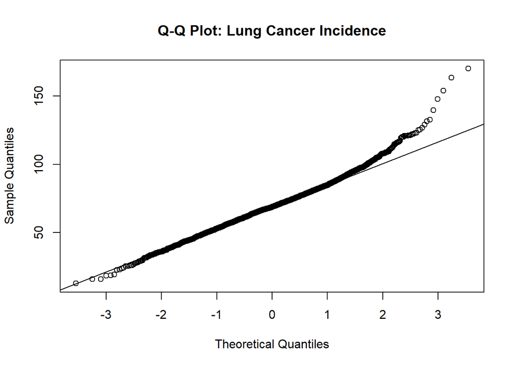

```r
# Generate Q-Q plots to visually assess the normality of continuous variables.
# If the data points roughly follow the reference line, the variable is approximately normally distributed.
# Normality helps determine which descriptive statistics to use:
# If normally distributed: use mean and standard deviation (SD)
# If not normally distributed: use median and interquartile range (IQR)

# Q-Q plot for Lung Cancer
qqnorm(lung.cancer$`Lung Cancer`, main = "Q-Q Plot: Lung Cancer Incidence")
qqline(lung.cancer$`Lung Cancer`)
```

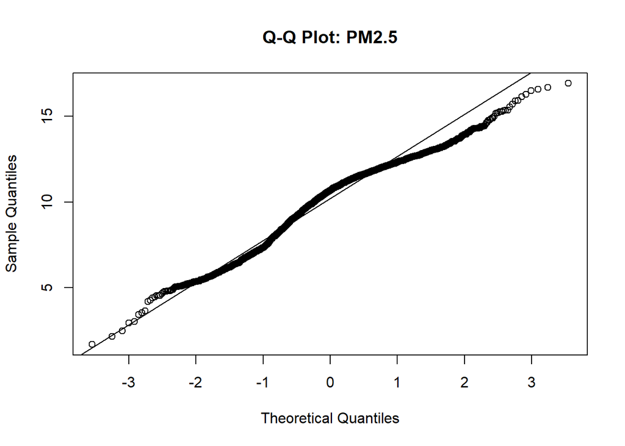

```r
# Q-Q plot for PM2.5
qqnorm(lung.cancer$`PM2.5`, main = "Q-Q Plot: PM2.5")
qqline(lung.cancer$`PM2.5`)
```

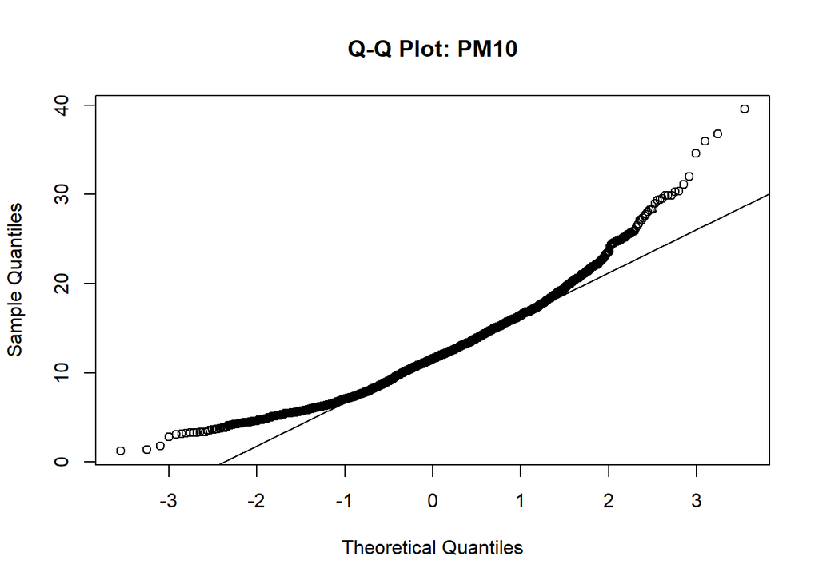

```r
# Q-Q plot for PM10
qqnorm(lung.cancer$PM10, main = "Q-Q Plot: PM10")
qqline(lung.cancer$PM10)
```

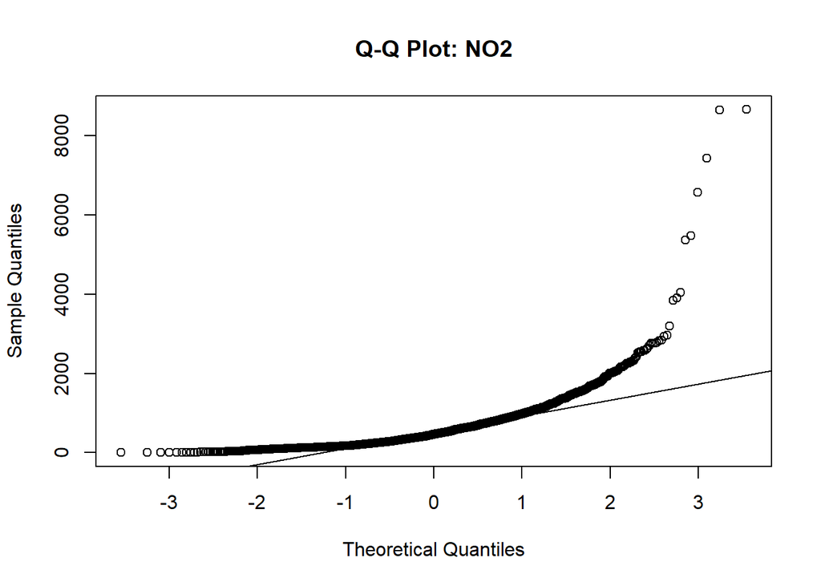

```r
# Q-Q plot for NO2
qqnorm(lung.cancer$NO2, main = "Q-Q Plot: NO2")
qqline(lung.cancer$NO2)
```

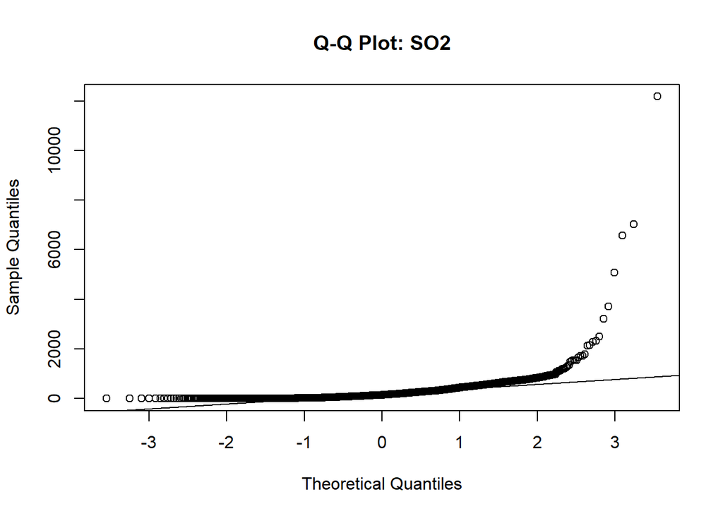

```r
# Q-Q plot for SO2
qqnorm(lung.cancer$SO2, main = "Q-Q Plot: SO2")
qqline(lung.cancer$SO2)
```

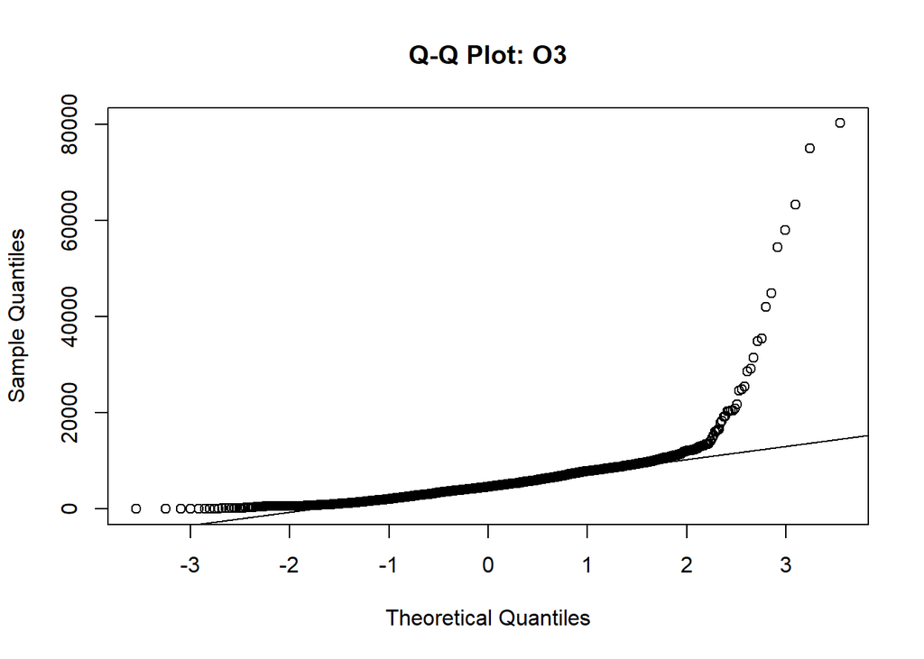

```r
# Q-Q plot for O3
qqnorm(lung.cancer$O3, main = "Q-Q Plot: O3")
qqline(lung.cancer$O3)
```

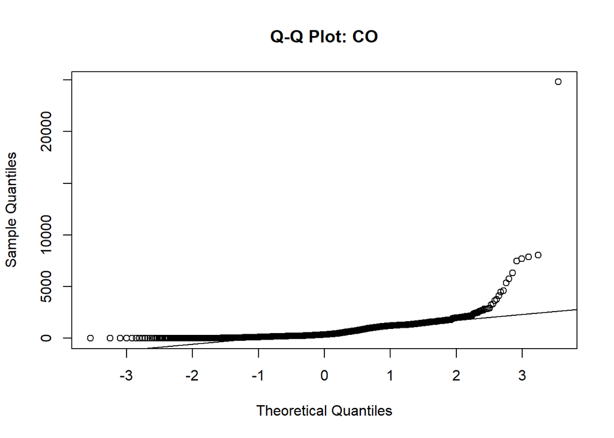

```r
# Q-Q plot for CO
qqnorm(lung.cancer$CO, main = "Q-Q Plot: CO")
qqline(lung.cancer$CO)
```

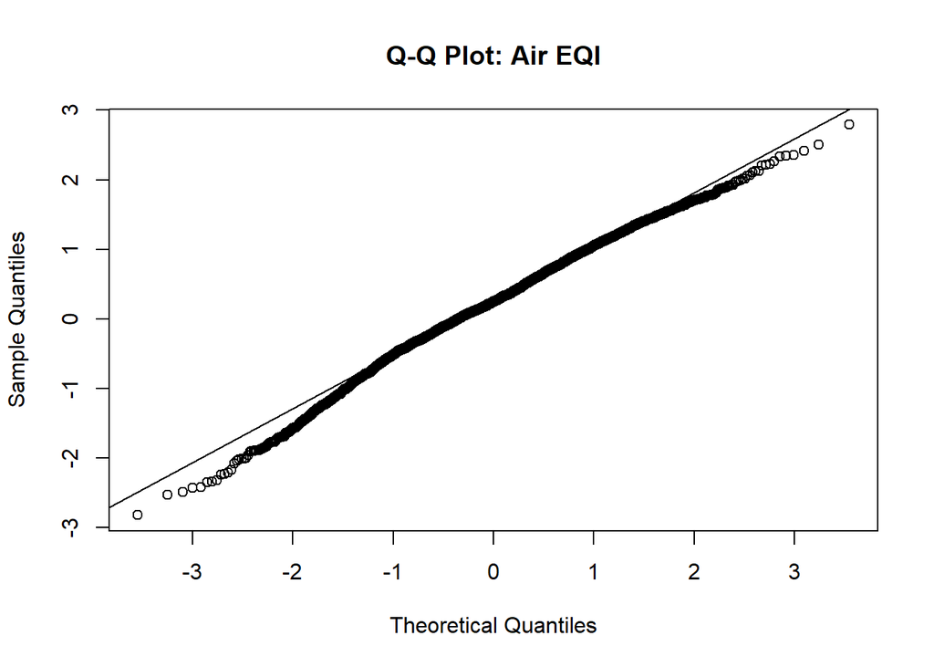

```r
# Q-Q plot for Air_EQI
qqnorm(lung.cancer$Air_EQI, main = "Q-Q Plot: Air EQI")
qqline(lung.cancer$Air_EQI)
```

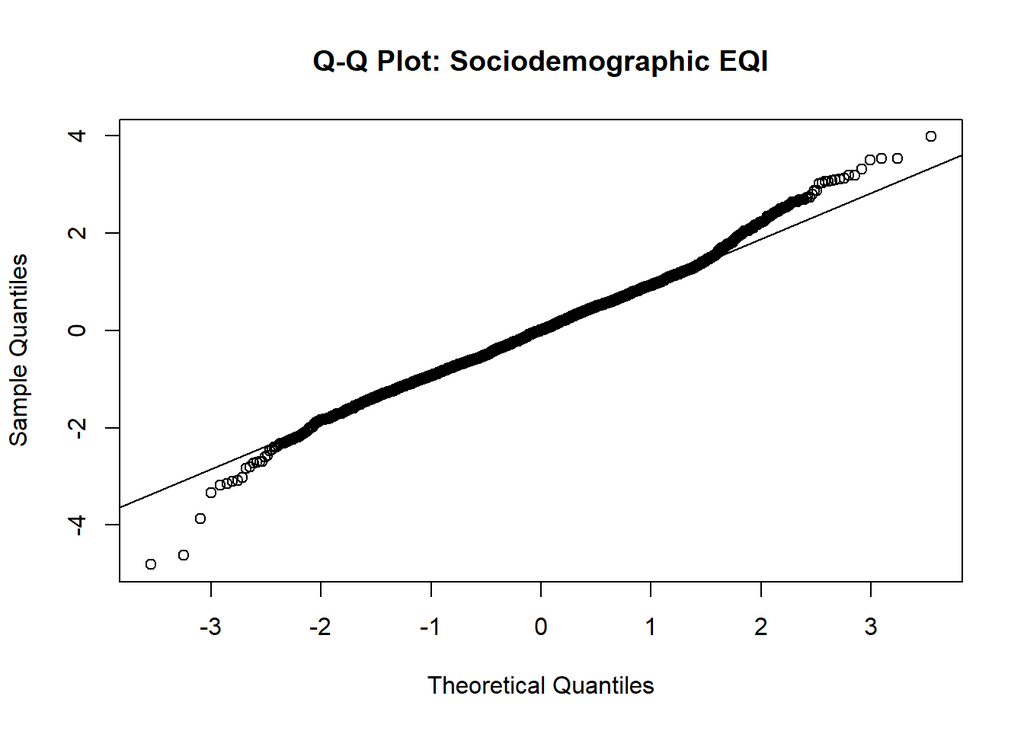

```r
# Q-Q plot for Sociod_EQI
qqnorm(lung.cancer$Sociod_EQI, main = "Q-Q Plot: Sociodemographic EQI")
qqline(lung.cancer$Sociod_EQI)
```

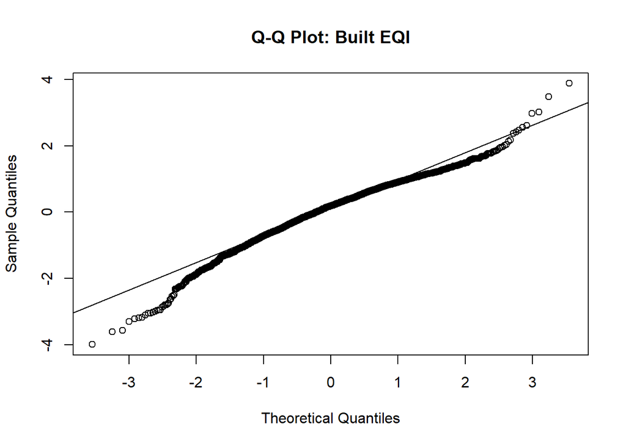

```r
# Q-Q plot for Built_EQI
qqnorm(lung.cancer$Built_EQI, main = "Q-Q Plot: Built EQI")
qqline(lung.cancer$Built_EQI)
```

```r
# Calculate summary statistics (mean & SD or median & IQR based on distribution)
lung_summary <- lung.cancer %>%
  summarise(
    mean_lung_cancer = mean(`Lung Cancer`, na.rm = TRUE),
    sd_lung_cancer = sd(`Lung Cancer`, na.rm = TRUE),

    mean_pm2_5 = mean(`PM2.5`, na.rm = TRUE),
    sd_pm2_5 = sd(`PM2.5`, na.rm = TRUE),

    mean_pm10 = mean(PM10, na.rm = TRUE),
    sd_pm10 = sd(PM10, na.rm = TRUE),

    mean_so2 = mean(SO2, na.rm = TRUE),
    sd_so2 = sd(SO2, na.rm = TRUE),

    mean_o3 = mean(O3, na.rm = TRUE),
    sd_o3 = sd(O3, na.rm = TRUE),

    mean_co = mean(CO, na.rm = TRUE),
    sd_co = sd(CO, na.rm = TRUE),

    median_no2 = median(NO2, na.rm = TRUE),
    iqr_no2 = IQR(NO2, na.rm = TRUE),

    mean_air_eqi = mean(Air_EQI, na.rm = TRUE),
    sd_air_eqi = sd(Air_EQI, na.rm = TRUE),

    mean_sociod_eqi = mean(Sociod_EQI, na.rm = TRUE),
    sd_sociod_eqi = sd(Sociod_EQI, na.rm = TRUE),

    mean_built_eqi = mean(Built_EQI, na.rm = TRUE),
    sd_built_eqi = sd(Built_EQI, na.rm = TRUE)
  )

lung_summary
```

```
## # A tibble: 1 × 20
##   mean_lung_cancer sd_lung_cancer mean_pm2_5 sd_pm2_5 mean_pm10 sd_pm10 mean_so2
##              <dbl>          <dbl>      <dbl>    <dbl>     <dbl>   <dbl>    <dbl>
## 1             69.4           17.3       10.2     2.31      12.0    4.84     237.
## # ℹ 13 more variables: sd_so2 <dbl>, mean_o3 <dbl>, sd_o3 <dbl>, mean_co <dbl>,
## #   sd_co <dbl>, median_no2 <dbl>, iqr_no2 <dbl>, mean_air_eqi <dbl>,
## #   sd_air_eqi <dbl>, mean_sociod_eqi <dbl>, sd_sociod_eqi <dbl>,
## #   mean_built_eqi <dbl>, sd_built_eqi <dbl>
```

```r
# Frequency count of Region Type (RT)
table(lung.cancer$RT)
```

```
##
## falling  rising  stable
##     237      51    2267
```

```r
# Percentage distribution of Region Type (RT)
prop.table(table(lung.cancer$RT)) * 100
```

```
##
##   falling    rising    stable
##  9.275930  1.996086 88.727984
```

## BIVARIATE ANALYSIS: PM2.5 and Lung Cancer Incidence:

#Assumptions for Pearson Correlation:

ASSUMPTION 1 - Independence of Observations :Each row in the dataset represents a unique county. There are no repeated measures or clustering, so this ASSUMPTION is MET.

ASSUMPTION 2- Both Variables are Continuous : PM2.5 (particulate matter concentration) and Lung Cancer incidence are continuous variables. This ASSUMPTION is MET.

ASSUMPTION 3 - Normal Distribution of Both Variables: We assess this using Q-Q plots for both PM2.5 and Lung Cancer incidence.

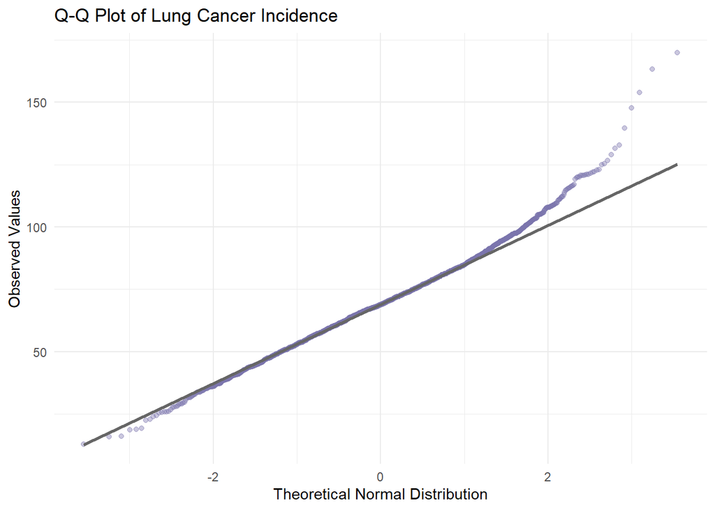

```r
# Q-Q plot to assess normality of Lung Cancer Incidence
ggplot(lung.cancer, aes(sample = `Lung Cancer`)) +
  stat_qq(alpha = 0.4, color = "#7A74AC") +
  stat_qq_line(color = "gray40", size = 1) +
  labs(
    title = "Q-Q Plot of Lung Cancer Incidence",
    x = "Theoretical Normal Distribution",
    y = "Observed Values"
  ) +
  theme_minimal()
```

#Interpretation of Q-Q Plot: Lung Cancer Incidence The Q-Q plot shows that most of the data points for lung cancer incidence fall closely along the reference line, with only mild deviations at the upper end. This indicates that the variable is approximately normally distributed, thereby meeting the assumption of normality required for parametric tests such as the Pearson correlation.

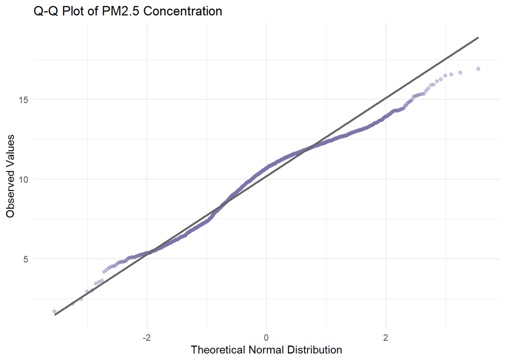

```r
# Q-Q plot to assess normality of PM2.5
ggplot(lung.cancer, aes(sample = `PM2.5`)) +
  stat_qq(alpha = 0.4, color = "#7A74AC") +
  stat_qq_line(color = "gray40", size = 1) +
  labs(
    title = "Q-Q Plot of PM2.5 Concentration",
    x = "Theoretical Normal Distribution",
    y = "Observed Values"
  ) +
  theme_minimal()
```

# Interpretation of Q-Q Plot: PM2.5 Concentration The Q-Q plot for PM2.5 concentration shows some slight deviations from the reference line in the lower and middle portions. However, the overall pattern still closely follows the line, indicating that the data is approximately normally distributed and meets the assumption of normality for Pearson correlation.

ASSUMPTION 4 - Linearity : A scatterplot with a linear regression line and LOESS curve is used to visually check if a linear relationship exists.

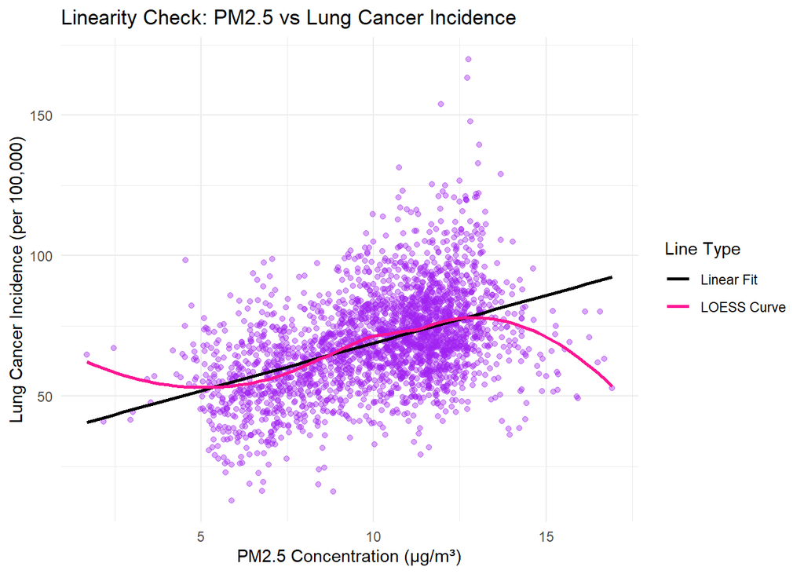

```r
# Scatterplot to check linear relationship between PM2.5 and Lung Cancer
library(ggplot2)

# Create the base plot
ggplot(lung.cancer, aes(x = `PM2.5`, y = `Lung Cancer`)) +
  geom_point(alpha = 0.4, color = "purple") +
  geom_smooth(method = "lm", se = FALSE, aes(color = "Linear Fit")) +
  geom_smooth(method = "loess", se = FALSE, aes(color = "LOESS Curve")) +

  # Customize the plot labels and theme
  labs(
    title = "Linearity Check: PM2.5 vs Lung Cancer Incidence",
    x = "PM2.5 Concentration (µg/m³)",
    y = "Lung Cancer Incidence (per 100,000)",
    color = "Line Type"  # Legend title
  ) +
  scale_color_manual(values = c("Linear Fit" = "black", "LOESS Curve" = "deeppink")) +
  theme_minimal()
```

#Interpretation of Linearity Check: PM2.5 vs Lung Cancer Incidence The scatterplot with both linear and LOESS trend lines shows a generally positive association between PM2.5 concentration and lung cancer incidence. While the LOESS curve indicates slight non-linear behavior at the extremes (lower and higher PM2.5 values), the linear regression line adequately captures the overall trend. Since the majority of the data points follow a roughly linear path, the assumption of linearity is reasonably met for the purposes of Pearson correlation.

ASSUMPTION 5 - Homoscedasticity (Equal Variance): We assess the assumption of homoscedasticity using a visual method, specifically the Residuals vs Fitted Values plot.

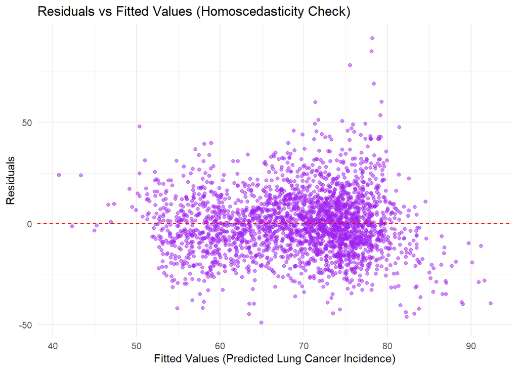

```r
# Fit a simple linear model for Pearson correlation visualization
model_homo <- lm(`Lung Cancer` ~ `PM2.5`, data = lung.cancer)

# Load required library
library(ggplot2)
library(broom)

# Extract residuals and fitted values
resid_df <- augment(model_homo)

# Plot residuals vs fitted values
ggplot(resid_df, aes(x = .fitted, y = .resid)) +
  geom_point(alpha = 0.5, color = "purple") +
  geom_hline(yintercept = 0, color = "red", linetype = "dashed") +
  labs(
    title = "Residuals vs Fitted Values (Homoscedasticity Check)",
    x = "Fitted Values (Predicted Lung Cancer Incidence)",
    y = "Residuals"
  ) +
  theme_minimal()
```

#Interpretation: The residuals appear to be evenly scattered around the horizontal line across the range of fitted values, with no clear systematic pattern or funnel shape. This indicates that the variance of residuals remains relatively constant, suggesting that the assumption of homoscedasticity is reasonably satisfied.

# All assumptions for Pearson correlation were checked and met:

# 1. Both variables (PM2.5 and Lung Cancer) are continuous

# 2. Observations are independent

# 3. Both variables are approximately normally distributed (via Q-Q plots)

# 4. The relationship between variables is approximately linear (confirmed by scatterplot)

# 5. The residuals show no clear pattern, indicating homoscedasticity (constant variance)

# Therefore, we proceed with the Pearson correlation test

```r
# Pearson correlation between PM2.5 and Lung Cancer
cor.test(lung.cancer$`PM2.5`, lung.cancer$`Lung Cancer`, method = "pearson")
```

```
##
##  Pearson's product-moment correlation
##
## data:  lung.cancer$PM2.5 and lung.cancer$`Lung Cancer`
## t = 25.658, df = 2553, p-value < 2.2e-16
## alternative hypothesis: true correlation is not equal to 0
## 95 percent confidence interval:
##  0.4213882 0.4830649
## sample estimates:
##      cor
## 0.452768
```

#Interpretation of Pearson Correlation: A Pearson correlation was conducted to assess the linear association between PM2.5 concentration and lung cancer incidence. The results showed a moderate positive correlation (r = 0.453, 95% CI [0.421, 0.483]), which was statistically significant (p < .001).

#Bivariate Visualization: PM2.5 and Lung Cancer Incidence To visually explore the relationship between PM2.5 concentration and lung cancer incidence, we created a scatterplot with a fitted linear trend line. This visualization helps illustrate the strength and direction of the association, supports the interpretation of the Pearson correlation results, and allows for quick identification of linear patterns or potential outliers across observations.

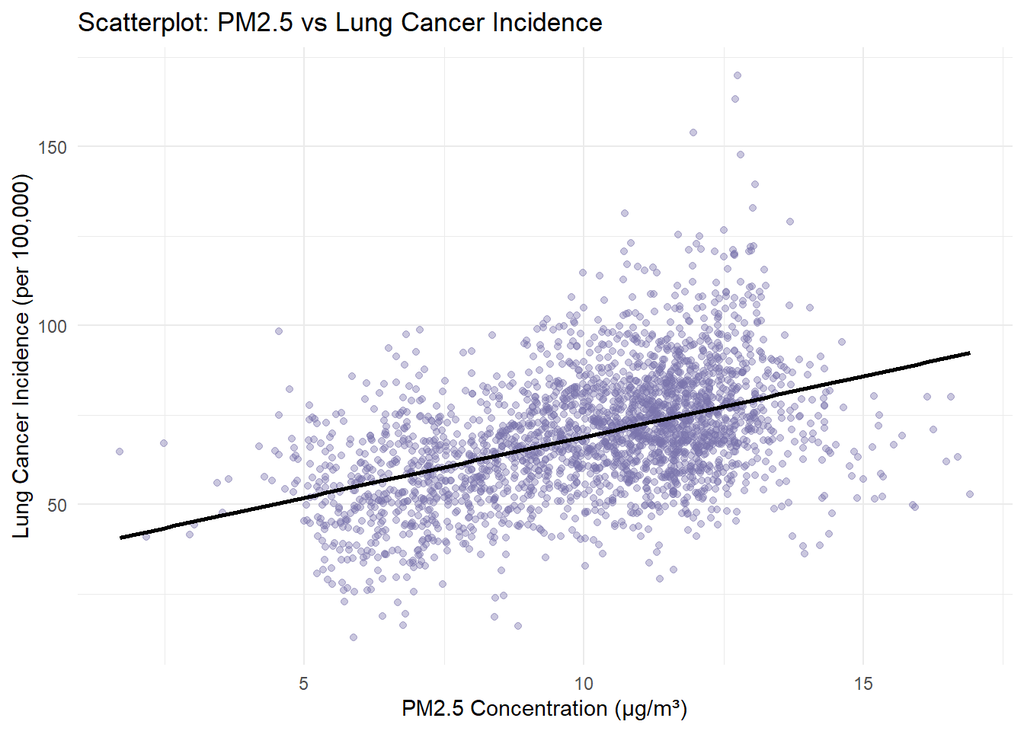

```r
# Scatterplot to visualize the bivariate relationship between PM2.5 and Lung Cancer Incidence
ggplot(lung.cancer, aes(x = `PM2.5`, y = `Lung Cancer`)) +
  geom_point(alpha = 0.4, color = "#7A74AC") +
  geom_smooth(method = "lm", se = FALSE, color = "black") +
  labs(
    title = "Scatterplot: PM2.5 vs Lung Cancer Incidence",
    x = "PM2.5 Concentration (µg/m³)",
    y = "Lung Cancer Incidence (per 100,000)"
  ) +
  theme_minimal()
```

#Interpretation of Bivariate Visualization: PM2.5 vs Lung Cancer Incidence The scatterplot illustrates the relationship between PM2.5 concentration (µg/m³) and lung cancer incidence (per 100,000). Each point represents an observation (e.g., a county).

The plot shows a positive linear trend, as visualized by the fitted regression line. As PM2.5 levels increase, lung cancer incidence also tends to rise. The clustering of points along an upward trajectory suggests a moderate positive association, consistent with the Pearson correlation result (r = 0.453).

This visualization supports the interpretation that higher levels of fine particulate air pollution (PM2.5) are associated with higher lung cancer rates across the observed regions.

#BIVARIATE ANALYSIS: PM2.5 and Regional Trend (RT) Assumptions for One-Way ANOVA (Tested Before ANOVA) ASSUMPTION 1 – Independence of Observations: Each row in the dataset represents a unique county assigned to only one RT group. There are no repeated measures or clustering. This ASSUMPTION is MET.

ASSUMPTION 2 – Dependent Variable is Continuous: PM2.5 (particulate matter concentration) is a continuous variable. This ASSUMPTION is MET.

ASSUMPTION 3 – Categorical Independent Variable: RT (Regional trends) is a categorical variable with three levels: falling, rising, and stable. This ASSUMPTION is MET.

ASSUMPTION 4 – Normality of Residuals Within Groups: Assessed using Shapiro-Wilk test for PM2.5 in each RT group.

```r
# Check normality of PM2.5 within each Regional Trends (RT) group using Shapiro-Wilk test
# Assesses whether PM2.5 values are approximately normally distributed within each group
# Required assumption check before running ANOVA
shapiro.test(lung.cancer$`PM2.5`[lung.cancer$RT == "falling"])
```

```
##
##  Shapiro-Wilk normality test
##
## data:  lung.cancer$PM2.5[lung.cancer$RT == "falling"]
## W = 0.99332, p-value = 0.3682
```

```r
shapiro.test(lung.cancer$`PM2.5`[lung.cancer$RT == "rising"])
```

```
##
##  Shapiro-Wilk normality test
##
## data:  lung.cancer$PM2.5[lung.cancer$RT == "rising"]
## W = 0.96748, p-value = 0.1734
```

```r
shapiro.test(lung.cancer$`PM2.5`[lung.cancer$RT == "stable"])
```

```
##
##  Shapiro-Wilk normality test
##
## data:  lung.cancer$PM2.5[lung.cancer$RT == "stable"]
## W = 0.96072, p-value < 2.2e-16
```

# Interpretation

Based on the p-values, the assumption of normality is met for the falling and rising groups. However, the stable group significantly deviates from normality (p < 0.001), violating the normality assumption.

ASSUMPTION 5 – Homogeneity of Variance: Evaluated using Levene’s Test.

```r
#levene's test for assumption of homogeneity of variance
library(car)
leveneTest(`PM2.5` ~ RT, data = lung.cancer)
```

```
## Levene's Test for Homogeneity of Variance (center = median)
##         Df F value  Pr(>F)
## group    2  3.2267 0.03985 *
##       2552
## ---
## Signif. codes:  0 '***' 0.001 '**' 0.01 '*' 0.05 '.' 0.1 ' ' 1
```

#Interpretation of Levene’s Test for Homogeneity of Variance Levene’s Test was conducted to assess the assumption of homogeneity of variance across the three Regional trends (RT) groups for PM2.5 levels. The test result, F(2, 2552) = 3.23, with a p-value of 0.03985, was statistically significant (p < 0.05). Therefore, we reject the null hypothesis of equal variances, indicating that the assumption of homogeneity of variance is violated.

Based on this outcome, Welch’s ANOVA was selected as the appropriate method for comparing group means, as it is robust to violations of variance equality and unequal sample sizes.

```r
# Perform Welch's ANOVA to compare PM2.5 across RT groups
oneway.test(`PM2.5` ~ RT, data = lung.cancer, var.equal = FALSE)
```

```
##
##  One-way analysis of means (not assuming equal variances)
##
## data:  PM2.5 and RT
## F = 4.1275, num df = 2.00, denom df = 118.94, p-value = 0.01849
```

#Interpretation A Welch’s ANOVA was conducted to determine whether there are significant differences in PM2.5 concentrations across the three Regional trends (RT) groups (falling, rising, and stable), without assuming equal variances. The test result was statistically significant, F(2, 118.94) = 4.13, p = 0.01849, indicating that the mean PM2.5 levels are not equal across all groups. Since the p-value is less than 0.05, we reject the null hypothesis and conclude that at least one RT group differs significantly in its average PM2.5 concentration.

# Post Hoc Analysis: Pairwise Comparisons Between RT Groups (Welch’s t-test with Bonferroni Adjustment)

Following a statistically significant Welch ANOVA, post hoc pairwise Welch t-tests with Bonferroni correction were conducted to identify which Regional trends (RT) groups differed significantly in their mean PM2.5 concentrations.

```r
#Pairwise Comparisons Between RT Groups (Welch’s t-test with Bonferroni Adjustment)
pairwise.t.test(lung.cancer$`PM2.5`, lung.cancer$RT,
                p.adjust.method = "bonferroni",
                pool.sd = FALSE)
```

```
##
##  Pairwise comparisons using t tests with non-pooled SD
##
## data:  lung.cancer$PM2.5 and lung.cancer$RT
##
##        falling rising
## rising 0.567   -
## stable 0.364   0.046
##
## P value adjustment method: bonferroni
```

# Interpretation

The results indicated a statistically significant difference between the Rising and Stable groups (p = 0.046), suggesting that these two RT categories had significantly different PM2.5 levels after adjusting for multiple comparisons. No significant differences were observed between: Falling vs Rising (p = 0.567) Falling vs Stable (p = 0.364)

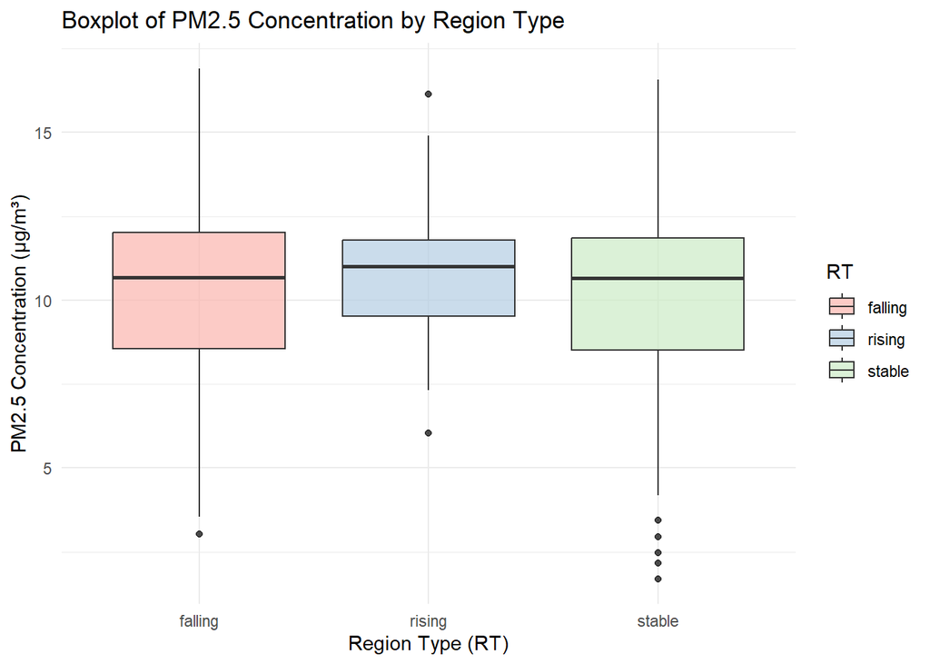

```r
# Create boxplot
ggplot(lung.cancer, aes(x = RT, y = `PM2.5`, fill = RT)) +
  geom_boxplot(alpha = 0.7, outlier.color = "black") +
  labs(
    title = "Boxplot of PM2.5 Concentration by Region Type",
    x = "Region Type (RT)",
    y = "PM2.5 Concentration (µg/m³)"
  ) +
  scale_fill_brewer(palette = "Pastel1") +
  theme_minimal()
```

# MULTIVARIATE ANALYSIS - Multiple Linear Regression

A multiple linear regression model was constructed to explore the relationship between log-transformed lung cancer incidence and four log-transformed predictors: PM2.5, CO, Sociod_EQI and Built_EQI.

```r
#  Log-transform variables (if not already done)
lung.cancer <- lung.cancer %>%
  mutate(
    log_LungCancer = log(`Lung Cancer` + 1),
    log_PM2_5 = log(`PM2.5` + 1),
    log_CO = log(CO + 1),
    log_Sociod_EQI = log(Sociod_EQI + abs(min(Sociod_EQI, na.rm = TRUE)) + 1),
    log_Built_EQI = log(Built_EQI + abs(min(Built_EQI, na.rm = TRUE)) + 1)
  )
```

```r
 #Fit the multiple linear regression model

model_final <- lm(log_LungCancer ~ log_PM2_5 + log_CO +
                    log_Sociod_EQI + log_Built_EQI,
                  data = lung.cancer)

summary(model_final)
```

```
##
## Call:
## lm(formula = log_LungCancer ~ log_PM2_5 + log_CO + log_Sociod_EQI +
##     log_Built_EQI, data = lung.cancer)
##
## Residuals:
##     Min      1Q  Median      3Q     Max
## -1.5933 -0.1185  0.0226  0.1427  0.7212
##
## Coefficients:
##                 Estimate Std. Error t value Pr(>|t|)
## (Intercept)     3.703526   0.070973  52.182  < 2e-16 ***
## log_PM2_5       0.525398   0.020464  25.674  < 2e-16 ***
## log_CO         -0.006494   0.003684  -1.763    0.078 .
## log_Sociod_EQI -0.289076   0.025629 -11.279  < 2e-16 ***
## log_Built_EQI  -0.119774   0.024459  -4.897 1.03e-06 ***
## ---
## Signif. codes:  0 '***' 0.001 '**' 0.01 '*' 0.05 '.' 0.1 ' ' 1
##
## Residual standard error: 0.2205 on 2550 degrees of freedom
## Multiple R-squared:  0.2842, Adjusted R-squared:  0.2831
## F-statistic: 253.1 on 4 and 2550 DF,  p-value: < 2.2e-16
```

#Assumption 1 – Independence of Observations Observations should be independent of one another. This means there are no repeated measures or clustering within the dataset. ASSUMPTION IS MET

#ASSUMPTION 2 - Linearity There must be a linear relationship between each continuous predictor and the outcome variable.

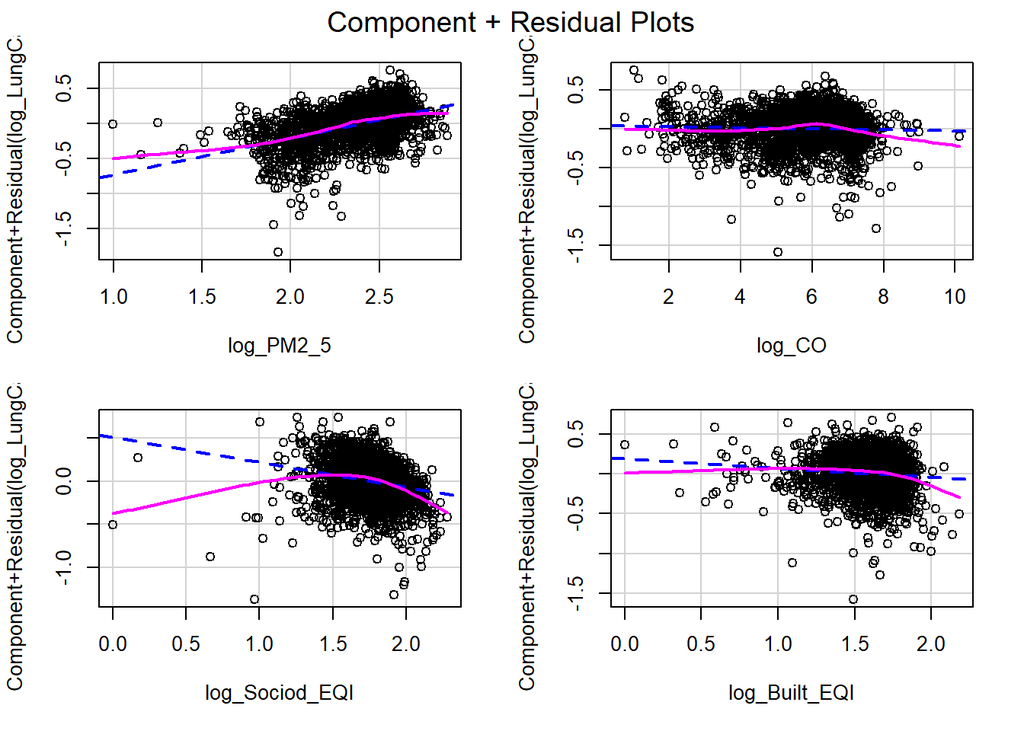

```r
library(car)
crPlots(model_final)
```

#Assumption 3 – Homoscedasticity Verified using Residual vs Fitted plot

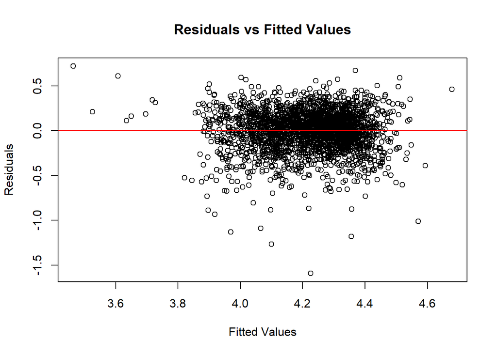

```r
plot(model_final$fitted.values, resid(model_final),
     xlab = "Fitted Values",
     ylab = "Residuals",
     main = "Residuals vs Fitted Values")
abline(h = 0, col = "red")
```

# Interpretation : While the residuals vs fitted values plot shows a slight increase in spread as fitted values increase, the overall pattern is not extreme. The points are still mostly centered around zero without severe funneling or curvature. Therefore, the assumption of homoscedasticity is “approximately met,” though mild heteroscedasticity is present.

#Assumption 4 – Normality of Residuals The residuals should be approximately normally distributed. Checked using Q-Q plots

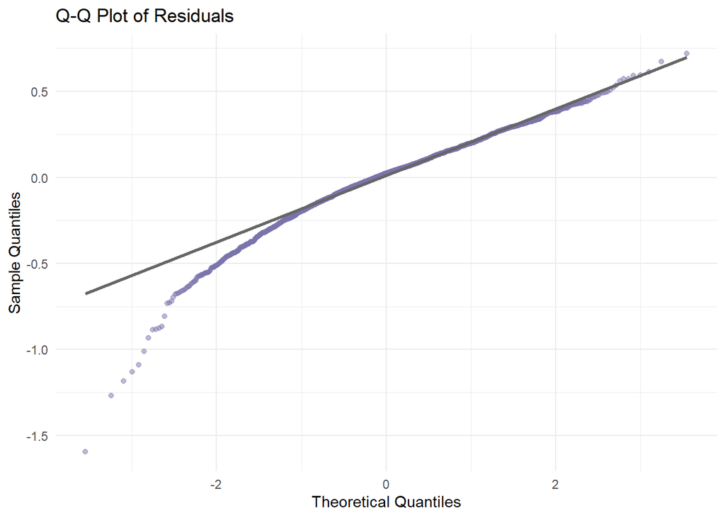

```r
# Q-Q Plot of residuals
residuals_df <- data.frame(residuals = resid(model_final))

ggplot(residuals_df, aes(sample = residuals)) +
  stat_qq(alpha = 0.5, color = "#7A74AC") +
  stat_qq_line(color = "gray40", size = 1) +
  labs(
    title = "Q-Q Plot of Residuals",
    x = "Theoretical Quantiles",
    y = "Sample Quantiles"
  ) +
  theme_minimal()
```